# Homework 2.2 Data Wrangling

Author

Andrew Joyce

Published

September 11, 2023

## Section 4.2.5

1. **In a single pipeline for each condition, find all flights that meet the following condition:**

```r
# Had an arrival delay of 2 or more hours
flights |>
  filter(arr_delay >= 120)
```

```
# A tibble: 10,200 × 19
    year month   day dep_time sched_dep_time dep_delay arr_time sched_arr_time
   <int> <int> <int>    <int>          <int>     <dbl>    <int>          <int>
 1  2013     1     1      811            630       101     1047            830
 2  2013     1     1      848           1835       853     1001           1950
 3  2013     1     1      957            733       144     1056            853
 4  2013     1     1     1114            900       134     1447           1222
 5  2013     1     1     1505           1310       115     1638           1431
 6  2013     1     1     1525           1340       105     1831           1626
 7  2013     1     1     1549           1445        64     1912           1656
 8  2013     1     1     1558           1359       119     1718           1515
 9  2013     1     1     1732           1630        62     2028           1825
10  2013     1     1     1803           1620       103     2008           1750
# ℹ 10,190 more rows
# ℹ 11 more variables: arr_delay <dbl>, carrier <chr>, flight <int>,
#   tailnum <chr>, origin <chr>, dest <chr>, air_time <dbl>, distance <dbl>,
#   hour <dbl>, minute <dbl>, time_hour <dttm>
```

```r
# Flew to Houston (IAH/HOU)
flights |>
  filter(dest %in% c("IAH", "HOU"))
```

```
# A tibble: 9,313 × 19
    year month   day dep_time sched_dep_time dep_delay arr_time sched_arr_time
   <int> <int> <int>    <int>          <int>     <dbl>    <int>          <int>
 1  2013     1     1      517            515         2      830            819
 2  2013     1     1      533            529         4      850            830
 3  2013     1     1      623            627        -4      933            932
 4  2013     1     1      728            732        -4     1041           1038
 5  2013     1     1      739            739         0     1104           1038
 6  2013     1     1      908            908         0     1228           1219
 7  2013     1     1     1028           1026         2     1350           1339
 8  2013     1     1     1044           1045        -1     1352           1351
 9  2013     1     1     1114            900       134     1447           1222
10  2013     1     1     1205           1200         5     1503           1505
# ℹ 9,303 more rows
# ℹ 11 more variables: arr_delay <dbl>, carrier <chr>, flight <int>,
#   tailnum <chr>, origin <chr>, dest <chr>, air_time <dbl>, distance <dbl>,
#   hour <dbl>, minute <dbl>, time_hour <dttm>
```

```r
# Were operated by United, Delta, or American
flights |>
  filter(carrier %in% c("UA", "DL", "AA"))
```

```
# A tibble: 139,504 × 19
    year month   day dep_time sched_dep_time dep_delay arr_time sched_arr_time
   <int> <int> <int>    <int>          <int>     <dbl>    <int>          <int>
 1  2013     1     1      517            515         2      830            819
 2  2013     1     1      533            529         4      850            830
 3  2013     1     1      542            540         2      923            850
 4  2013     1     1      554            600        -6      812            837
 5  2013     1     1      554            558        -4      740            728
 6  2013     1     1      558            600        -2      753            745
 7  2013     1     1      558            600        -2      924            917
 8  2013     1     1      558            600        -2      923            937
 9  2013     1     1      559            600        -1      941            910
10  2013     1     1      559            600        -1      854            902
# ℹ 139,494 more rows
# ℹ 11 more variables: arr_delay <dbl>, carrier <chr>, flight <int>,
#   tailnum <chr>, origin <chr>, dest <chr>, air_time <dbl>, distance <dbl>,
#   hour <dbl>, minute <dbl>, time_hour <dttm>
```

```r
# Departed in summer (July- September)
flights |>
  filter(month %in% c(7:9))
```

```
# A tibble: 86,326 × 19
    year month   day dep_time sched_dep_time dep_delay arr_time sched_arr_time
   <int> <int> <int>    <int>          <int>     <dbl>    <int>          <int>
 1  2013     7     1        1           2029       212      236           2359
 2  2013     7     1        2           2359         3      344            344
 3  2013     7     1       29           2245       104      151              1
 4  2013     7     1       43           2130       193      322             14
 5  2013     7     1       44           2150       174      300            100
 6  2013     7     1       46           2051       235      304           2358
 7  2013     7     1       48           2001       287      308           2305
 8  2013     7     1       58           2155       183      335             43
 9  2013     7     1      100           2146       194      327             30
10  2013     7     1      100           2245       135      337            135
# ℹ 86,316 more rows
# ℹ 11 more variables: arr_delay <dbl>, carrier <chr>, flight <int>,
#   tailnum <chr>, origin <chr>, dest <chr>, air_time <dbl>, distance <dbl>,
#   hour <dbl>, minute <dbl>, time_hour <dttm>
```

```r
# Arrived more than two hours late, but didn’t leave late
flights |>
  filter(arr_delay > 120 & dep_delay <= 0)
```

```
# A tibble: 29 × 19
    year month   day dep_time sched_dep_time dep_delay arr_time sched_arr_time
   <int> <int> <int>    <int>          <int>     <dbl>    <int>          <int>
 1  2013     1    27     1419           1420        -1     1754           1550
 2  2013    10     7     1350           1350         0     1736           1526
 3  2013    10     7     1357           1359        -2     1858           1654
 4  2013    10    16      657            700        -3     1258           1056
 5  2013    11     1      658            700        -2     1329           1015
 6  2013     3    18     1844           1847        -3       39           2219
 7  2013     4    17     1635           1640        -5     2049           1845
 8  2013     4    18      558            600        -2     1149            850
 9  2013     4    18      655            700        -5     1213            950
10  2013     5    22     1827           1830        -3     2217           2010
# ℹ 19 more rows
# ℹ 11 more variables: arr_delay <dbl>, carrier <chr>, flight <int>,
#   tailnum <chr>, origin <chr>, dest <chr>, air_time <dbl>, distance <dbl>,
#   hour <dbl>, minute <dbl>, time_hour <dttm>
```

```r
#Were delayed by at least an hour, but made up over 30 minutes in flight
flights |>
  filter(dep_delay >= 60 & arr_delay < dep_delay - 30)
```

```
# A tibble: 1,844 × 19
    year month   day dep_time sched_dep_time dep_delay arr_time sched_arr_time
   <int> <int> <int>    <int>          <int>     <dbl>    <int>          <int>
 1  2013     1     1     2205           1720       285       46           2040
 2  2013     1     1     2326           2130       116      131             18
 3  2013     1     3     1503           1221       162     1803           1555
 4  2013     1     3     1839           1700        99     2056           1950
 5  2013     1     3     1850           1745        65     2148           2120
 6  2013     1     3     1941           1759       102     2246           2139
 7  2013     1     3     1950           1845        65     2228           2227
 8  2013     1     3     2015           1915        60     2135           2111
 9  2013     1     3     2257           2000       177       45           2224
10  2013     1     4     1917           1700       137     2135           1950
# ℹ 1,834 more rows
# ℹ 11 more variables: arr_delay <dbl>, carrier <chr>, flight <int>,
#   tailnum <chr>, origin <chr>, dest <chr>, air_time <dbl>, distance <dbl>,
#   hour <dbl>, minute <dbl>, time_hour <dttm>
```

2. **Sort `flights` to find the flights with the longest departure delays. Find the flights that left earliest in the morning.**

```r
# arranging flights by length of departure delay (longest to shortest) to find flights with longest departure delays
flights |>
  arrange(desc(dep_delay))
```

```
# A tibble: 336,776 × 19
    year month   day dep_time sched_dep_time dep_delay arr_time sched_arr_time
   <int> <int> <int>    <int>          <int>     <dbl>    <int>          <int>
 1  2013     1     9      641            900      1301     1242           1530
 2  2013     6    15     1432           1935      1137     1607           2120
 3  2013     1    10     1121           1635      1126     1239           1810
 4  2013     9    20     1139           1845      1014     1457           2210
 5  2013     7    22      845           1600      1005     1044           1815
 6  2013     4    10     1100           1900       960     1342           2211
 7  2013     3    17     2321            810       911      135           1020
 8  2013     6    27      959           1900       899     1236           2226
 9  2013     7    22     2257            759       898      121           1026
10  2013    12     5      756           1700       896     1058           2020
# ℹ 336,766 more rows
# ℹ 11 more variables: arr_delay <dbl>, carrier <chr>, flight <int>,
#   tailnum <chr>, origin <chr>, dest <chr>, air_time <dbl>, distance <dbl>,
#   hour <dbl>, minute <dbl>, time_hour <dttm>
```

```r
# arranging flights by departure time (earliest to latest) to find flights that left earliest in the morning
flights |> arrange(dep_time)
```

```
# A tibble: 336,776 × 19
    year month   day dep_time sched_dep_time dep_delay arr_time sched_arr_time
   <int> <int> <int>    <int>          <int>     <dbl>    <int>          <int>
 1  2013     1    13        1           2249        72      108           2357
 2  2013     1    31        1           2100       181      124           2225
 3  2013    11    13        1           2359         2      442            440
 4  2013    12    16        1           2359         2      447            437
 5  2013    12    20        1           2359         2      430            440
 6  2013    12    26        1           2359         2      437            440
 7  2013    12    30        1           2359         2      441            437
 8  2013     2    11        1           2100       181      111           2225
 9  2013     2    24        1           2245        76      121           2354
10  2013     3     8        1           2355         6      431            440
# ℹ 336,766 more rows
# ℹ 11 more variables: arr_delay <dbl>, carrier <chr>, flight <int>,
#   tailnum <chr>, origin <chr>, dest <chr>, air_time <dbl>, distance <dbl>,
#   hour <dbl>, minute <dbl>, time_hour <dttm>
```

3. **Sort `flights` to find the fastest flights.**

```r
flights |> arrange(air_time)
```

```
# A tibble: 336,776 × 19
    year month   day dep_time sched_dep_time dep_delay arr_time sched_arr_time
   <int> <int> <int>    <int>          <int>     <dbl>    <int>          <int>
 1  2013     1    16     1355           1315        40     1442           1411
 2  2013     4    13      537            527        10      622            628
 3  2013    12     6      922            851        31     1021            954
 4  2013     2     3     2153           2129        24     2247           2224
 5  2013     2     5     1303           1315       -12     1342           1411
 6  2013     2    12     2123           2130        -7     2211           2225
 7  2013     3     2     1450           1500       -10     1547           1608
 8  2013     3     8     2026           1935        51     2131           2056
 9  2013     3    18     1456           1329        87     1533           1426
10  2013     3    19     2226           2145        41     2305           2246
# ℹ 336,766 more rows
# ℹ 11 more variables: arr_delay <dbl>, carrier <chr>, flight <int>,
#   tailnum <chr>, origin <chr>, dest <chr>, air_time <dbl>, distance <dbl>,
#   hour <dbl>, minute <dbl>, time_hour <dttm>
```

4. **Was there a flight on every day of 2013?**

```r
flights |>
  distinct(month, day)
```

```
# A tibble: 365 × 2
   month   day
   <int> <int>
 1     1     1
 2     1     2
 3     1     3
 4     1     4
 5     1     5
 6     1     6
 7     1     7
 8     1     8
 9     1     9
10     1    10
# ℹ 355 more rows
```

Because there are 365 distinct pairs of months and days, there were indeed flights every day of 2013.

5. **Which flights traveled the farthest distance? The least distance?**

```r
# To view flights that traveled the farthest distance
flights |>
  arrange(desc(distance))
```

```
# A tibble: 336,776 × 19
    year month   day dep_time sched_dep_time dep_delay arr_time sched_arr_time
   <int> <int> <int>    <int>          <int>     <dbl>    <int>          <int>
 1  2013     1     1      857            900        -3     1516           1530
 2  2013     1     2      909            900         9     1525           1530
 3  2013     1     3      914            900        14     1504           1530
 4  2013     1     4      900            900         0     1516           1530
 5  2013     1     5      858            900        -2     1519           1530
 6  2013     1     6     1019            900        79     1558           1530
 7  2013     1     7     1042            900       102     1620           1530
 8  2013     1     8      901            900         1     1504           1530
 9  2013     1     9      641            900      1301     1242           1530
10  2013     1    10      859            900        -1     1449           1530
# ℹ 336,766 more rows
# ℹ 11 more variables: arr_delay <dbl>, carrier <chr>, flight <int>,
#   tailnum <chr>, origin <chr>, dest <chr>, air_time <dbl>, distance <dbl>,
#   hour <dbl>, minute <dbl>, time_hour <dttm>
```

```r
# To view flights that traveled the least distance
flights |>
  arrange(distance)
```

```
# A tibble: 336,776 × 19
    year month   day dep_time sched_dep_time dep_delay arr_time sched_arr_time
   <int> <int> <int>    <int>          <int>     <dbl>    <int>          <int>
 1  2013     7    27       NA            106        NA       NA            245
 2  2013     1     3     2127           2129        -2     2222           2224
 3  2013     1     4     1240           1200        40     1333           1306
 4  2013     1     4     1829           1615       134     1937           1721
 5  2013     1     4     2128           2129        -1     2218           2224
 6  2013     1     5     1155           1200        -5     1241           1306
 7  2013     1     6     2125           2129        -4     2224           2224
 8  2013     1     7     2124           2129        -5     2212           2224
 9  2013     1     8     2127           2130        -3     2304           2225
10  2013     1     9     2126           2129        -3     2217           2224
# ℹ 336,766 more rows
# ℹ 11 more variables: arr_delay <dbl>, carrier <chr>, flight <int>,
#   tailnum <chr>, origin <chr>, dest <chr>, air_time <dbl>, distance <dbl>,
#   hour <dbl>, minute <dbl>, time_hour <dttm>
```

6. **Does it matter what order you used `filter()` and `arrange()` if you’re using both? Why/why not? Think about the results and how much work the functions would have to do.**

Yes, the order does matter- though the output is the same, the order matters in terms of computing power.

The function `arrange()` sorts every single row in the data. The function `filter()` removes rows of data.  
By using the function `filter()` first, you’ll end up arranging only the rows of interest. It will be less work for the function to use `filter()` first and then use `arrange()`.

For example, I am curious about the longest departure delays from the carrier American Airlines. I will run two blocks of code: the first in the preferred `filter()` then `arrange()` sequence, and the second in the less desired `arrange()` then `filter()` sequence.

```r
flights |>
  filter(carrier == "AA") |>
  arrange(desc(dep_delay))
```

```
# A tibble: 32,729 × 19
    year month   day dep_time sched_dep_time dep_delay arr_time sched_arr_time
   <int> <int> <int>    <int>          <int>     <dbl>    <int>          <int>
 1  2013     9    20     1139           1845      1014     1457           2210
 2  2013    12     5      756           1700       896     1058           2020
 3  2013     5    19      713           1700       853     1007           1955
 4  2013    12    17      705           1700       845     1026           2020
 5  2013     6    27      753           1830       803      937           2015
 6  2013     4    19      617           1700       797      858           1955
 7  2013     4    19      606           1725       761      923           2020
 8  2013    12    15      625           1925       660      933           2245
 9  2013    11    24     2301           1225       636      149           1535
10  2013     6     5     2028           1015       613     2308           1310
# ℹ 32,719 more rows
# ℹ 11 more variables: arr_delay <dbl>, carrier <chr>, flight <int>,
#   tailnum <chr>, origin <chr>, dest <chr>, air_time <dbl>, distance <dbl>,
#   hour <dbl>, minute <dbl>, time_hour <dttm>
```

```r
flights |>
  arrange(desc(dep_delay)) |>
  filter(carrier == "AA")
```

```
# A tibble: 32,729 × 19
    year month   day dep_time sched_dep_time dep_delay arr_time sched_arr_time
   <int> <int> <int>    <int>          <int>     <dbl>    <int>          <int>
 1  2013     9    20     1139           1845      1014     1457           2210
 2  2013    12     5      756           1700       896     1058           2020
 3  2013     5    19      713           1700       853     1007           1955
 4  2013    12    17      705           1700       845     1026           2020
 5  2013     6    27      753           1830       803      937           2015
 6  2013     4    19      617           1700       797      858           1955
 7  2013     4    19      606           1725       761      923           2020
 8  2013    12    15      625           1925       660      933           2245
 9  2013    11    24     2301           1225       636      149           1535
10  2013     6     5     2028           1015       613     2308           1310
# ℹ 32,719 more rows
# ℹ 11 more variables: arr_delay <dbl>, carrier <chr>, flight <int>,
#   tailnum <chr>, origin <chr>, dest <chr>, air_time <dbl>, distance <dbl>,
#   hour <dbl>, minute <dbl>, time_hour <dttm>
```

Note that the output is the same. So in one sense, it does not matter, since we get the same answer. However, by filtering first, the work of arranging is lessened. So, if I were using a massive data set with millions of rows, I would definitely want to filter first.

## Section 4.3.5

1. **Compare `dep_time`, `sched_dep_time`, and `dep_delay`. How would you expect those three numbers to be related?**

2. **Brainstorm as many ways as possible to select `dep_time`, `dep_delay`, `arr_time`, and `arr_delay` from `flights`.**

```r
# list desired columns separating with a comma
flights |>
  select(dep_time, dep_delay, arr_time, arr_delay)
```

```
# A tibble: 336,776 × 4
   dep_time dep_delay arr_time arr_delay
      <int>     <dbl>    <int>     <dbl>
 1      517         2      830        11
 2      533         4      850        20
 3      542         2      923        33
 4      544        -1     1004       -18
 5      554        -6      812       -25
 6      554        -4      740        12
 7      555        -5      913        19
 8      557        -3      709       -14
 9      557        -3      838        -8
10      558        -2      753         8
# ℹ 336,766 more rows
```

```r
# use a colon to select a range of columns
flights |>
  select(dep_time, dep_delay:arr_time, arr_delay)
```

```
# A tibble: 336,776 × 4
   dep_time dep_delay arr_time arr_delay
      <int>     <dbl>    <int>     <dbl>
 1      517         2      830        11
 2      533         4      850        20
 3      542         2      923        33
 4      544        -1     1004       -18
 5      554        -6      812       -25
 6      554        -4      740        12
 7      555        -5      913        19
 8      557        -3      709       -14
 9      557        -3      838        -8
10      558        -2      753         8
# ℹ 336,766 more rows
```

```r
#use an exclamation point to select by excluding a column or range of columns
flights |>
  select(!(year:day) & !sched_dep_time & !sched_arr_time & !(carrier:time_hour))
```

```
# A tibble: 336,776 × 4
   dep_time dep_delay arr_time arr_delay
      <int>     <dbl>    <int>     <dbl>
 1      517         2      830        11
 2      533         4      850        20
 3      542         2      923        33
 4      544        -1     1004       -18
 5      554        -6      812       -25
 6      554        -4      740        12
 7      555        -5      913        19
 8      557        -3      709       -14
 9      557        -3      838        -8
10      558        -2      753         8
# ℹ 336,766 more rows
```

3. **What happens if you specify the name of the same variable multiple times in a `select()` call?**

If you repeat the same variable, it will only appear once in the output.

```r
flights |>
  select(dep_time, dep_delay, arr_time, arr_delay, arr_time, arr_time, arr_time)
```

```
# A tibble: 336,776 × 4
   dep_time dep_delay arr_time arr_delay
      <int>     <dbl>    <int>     <dbl>
 1      517         2      830        11
 2      533         4      850        20
 3      542         2      923        33
 4      544        -1     1004       -18
 5      554        -6      812       -25
 6      554        -4      740        12
 7      555        -5      913        19
 8      557        -3      709       -14
 9      557        -3      838        -8
10      558        -2      753         8
# ℹ 336,766 more rows
```

Though I specified `arr_time 4` separate times In the code, it only appears once in the output.

4. **What does the `any_of()` function do? Why might it be helpful in conjunction with this vector?**

The `any_of()` function will select for any variables within a character vector. Since the function does not look for missing variables, an error will not occur if any variables are missing.

For example, take the following vector:

```
variables <- c("year", "month", "day", "dep_delay", "arr_delay")
```

We can use this object, a character vector titled `variables`, to select from the flights data.

```r
variables <- c("year", "month", "day", "dep_delay", "arr_delay")
flights |>
  select(any_of(variables))
```

```
# A tibble: 336,776 × 5
    year month   day dep_delay arr_delay
   <int> <int> <int>     <dbl>     <dbl>
 1  2013     1     1         2        11
 2  2013     1     1         4        20
 3  2013     1     1         2        33
 4  2013     1     1        -1       -18
 5  2013     1     1        -6       -25
 6  2013     1     1        -4        12
 7  2013     1     1        -5        19
 8  2013     1     1        -3       -14
 9  2013     1     1        -3        -8
10  2013     1     1        -2         8
# ℹ 336,766 more rows
```

Or, we can use the same vector to quickly exclude those variables from the data.

```r
flights |>
  select(!any_of(variables))
```

```
# A tibble: 336,776 × 14
   dep_time sched_dep_time arr_time sched_arr_time carrier flight tailnum origin
      <int>          <int>    <int>          <int> <chr>    <int> <chr>   <chr>
 1      517            515      830            819 UA        1545 N14228  EWR
 2      533            529      850            830 UA        1714 N24211  LGA
 3      542            540      923            850 AA        1141 N619AA  JFK
 4      544            545     1004           1022 B6         725 N804JB  JFK
 5      554            600      812            837 DL         461 N668DN  LGA
 6      554            558      740            728 UA        1696 N39463  EWR
 7      555            600      913            854 B6         507 N516JB  EWR
 8      557            600      709            723 EV        5708 N829AS  LGA
 9      557            600      838            846 B6          79 N593JB  JFK
10      558            600      753            745 AA         301 N3ALAA  LGA
# ℹ 336,766 more rows
# ℹ 6 more variables: dest <chr>, air_time <dbl>, distance <dbl>, hour <dbl>,
#   minute <dbl>, time_hour <dttm>
```

Since we’ve created a character vector, we can reference that in our code instead of repeatedly typing the same five variables over and over.

5. **Does the result of running the following code surprise you? How do the select helpers deal with upper and lower case by default? How can you change that default?**

```r
flights |> select(contains("TIME"))
```

```
# A tibble: 336,776 × 6
   dep_time sched_dep_time arr_time sched_arr_time air_time time_hour
      <int>          <int>    <int>          <int>    <dbl> <dttm>
 1      517            515      830            819      227 2013-01-01 05:00:00
 2      533            529      850            830      227 2013-01-01 05:00:00
 3      542            540      923            850      160 2013-01-01 05:00:00
 4      544            545     1004           1022      183 2013-01-01 05:00:00
 5      554            600      812            837      116 2013-01-01 06:00:00
 6      554            558      740            728      150 2013-01-01 05:00:00
 7      555            600      913            854      158 2013-01-01 06:00:00
 8      557            600      709            723       53 2013-01-01 06:00:00
 9      557            600      838            846      140 2013-01-01 06:00:00
10      558            600      753            745      138 2013-01-01 06:00:00
# ℹ 336,766 more rows
```

This chunk shows any column that contains “TIME” in its name. However, the default is to ignore the case of the text. So no matter if I typed “TIME” or “time” I will get the same result. I can change this by specifying `ignore.case = FALSE` (the default is TRUE):

```r
flights |> select(contains("TIME", ignore.case=FALSE))
```

```
# A tibble: 336,776 × 0
```

Because I specified within the command to *not* ignore the case of column names, no columns are returned since all the column names in the data are in lower case.

6. **Rename `air_time` to `air_time_min` to indicate units of measurement and move it to the beginning of the data frame.**

```r
flights |>
  rename(air_time_min = air_time) |> relocate(air_time_min)
```

```
# A tibble: 336,776 × 19
   air_time_min  year month   day dep_time sched_dep_time dep_delay arr_time
          <dbl> <int> <int> <int>    <int>          <int>     <dbl>    <int>
 1          227  2013     1     1      517            515         2      830
 2          227  2013     1     1      533            529         4      850
 3          160  2013     1     1      542            540         2      923
 4          183  2013     1     1      544            545        -1     1004
 5          116  2013     1     1      554            600        -6      812
 6          150  2013     1     1      554            558        -4      740
 7          158  2013     1     1      555            600        -5      913
 8           53  2013     1     1      557            600        -3      709
 9          140  2013     1     1      557            600        -3      838
10          138  2013     1     1      558            600        -2      753
# ℹ 336,766 more rows
# ℹ 11 more variables: sched_arr_time <int>, arr_delay <dbl>, carrier <chr>,
#   flight <int>, tailnum <chr>, origin <chr>, dest <chr>, distance <dbl>,
#   hour <dbl>, minute <dbl>, time_hour <dttm>
```

6. **Why doesn’t the following work, and what does the error mean?**

```
flights |>
  select(tailnum) |>
  arrange(arr_delay)
#> Error in `arrange()`:
#> ℹ In argument: `..1 = arr_delay`.
#> Caused by error:
#> ! object 'arr_delay' not found
```

The command `select()` chooses variables of interest. Here, the second line of code says to select only the column `tailnum`. Only one column is selected. So, the third line command to arrange by `arr_delay` fails because only one column has been selected. After `arrange()`, R is looking for an object- usually a variable name. But since we’ve previously selected one (and only one) column, `tailnum`, there is no object named `arr_delay` to be found.

## Section 4.5.7

1. **Which carrier has the worst average delays? Challenge: can you disentangle the effects of bad airports vs. bad carriers? Why/why not? (Hint: think about `flights |> group_by(carrier, dest) |> summarize(n())`)**

To find out which carrier has the worst average departure delay:

```r
flights |>
  group_by(carrier) |>
  summarize(avgdelay = mean(dep_delay, na.rm=TRUE)) |>
  arrange(desc(avgdelay))
```

```
# A tibble: 16 × 2
   carrier avgdelay
   <chr>      <dbl>
 1 F9         20.2
 2 EV         20.0
 3 YV         19.0
 4 FL         18.7
 5 WN         17.7
 6 9E         16.7
 7 B6         13.0
 8 VX         12.9
 9 OO         12.6
10 UA         12.1
11 MQ         10.6
12 DL          9.26
13 AA          8.59
14 AS          5.80
15 HA          4.90
16 US          3.78
```

Frontier Airlines ([F9](https://aspm.faa.gov/aspmhelp/index/ASQP__Carrier_Codes_and_Names.html)) has the worst average departure delays.

Conceptually, It will not be easy to disentangle the effects of bad carriers versus bad airports. There are 16 distinct carriers. There are 105 distinct destinations, and 3 distinct origins. There are 224 unique routes (unique combinations of origin & destination). There are 439 total carrier-routes (unique combinations of carrier, origin, and destination).

```r
# number of distinct carriers, destinations, and origins
flights |>
  summarize(n_distinct(carrier),
            n_distinct(dest),
            n_distinct(origin))
```

```
# A tibble: 1 × 3
  `n_distinct(carrier)` `n_distinct(dest)` `n_distinct(origin)`
                  <int>              <int>                <int>
1                    16                105                    3
```

```r
# distinct origin-destination pairs (unique routes, no matter the carrier)
flights  |> distinct(origin, dest)
```

```
# A tibble: 224 × 2
   origin dest
   <chr>  <chr>
 1 EWR    IAH
 2 LGA    IAH
 3 JFK    MIA
 4 JFK    BQN
 5 LGA    ATL
 6 EWR    ORD
 7 EWR    FLL
 8 LGA    IAD
 9 JFK    MCO
10 LGA    ORD
# ℹ 214 more rows
```

```r
# distinct carrier routes (origin, dest, carrier pairs)
flights |> distinct(carrier, origin, dest)
```

```
# A tibble: 439 × 3
   carrier origin dest
   <chr>   <chr>  <chr>
 1 UA      EWR    IAH
 2 UA      LGA    IAH
 3 AA      JFK    MIA
 4 B6      JFK    BQN
 5 DL      LGA    ATL
 6 UA      EWR    ORD
 7 B6      EWR    FLL
 8 EV      LGA    IAD
 9 B6      JFK    MCO
10 AA      LGA    ORD
# ℹ 429 more rows
```

```r
# average departrue delays by carrier per airport
flights |>
  group_by(origin, carrier) |>
  summarize(avgdelay = mean(dep_delay, na.rm=TRUE)) |>
  arrange(desc(avgdelay))
```

```
# A tibble: 35 × 3
# Groups:   origin [3]
   origin carrier avgdelay
   <chr>  <chr>      <dbl>
 1 EWR    OO          20.8
 2 LGA    F9          20.2
 3 EWR    EV          20.2
 4 LGA    EV          19.1
 5 JFK    9E          19.0
 6 LGA    YV          19.0
 7 LGA    FL          18.7
 8 JFK    EV          18.5
 9 EWR    WN          17.9
10 LGA    WN          17.6
# ℹ 25 more rows
```

I’m not sure if the data can answer this question, since not every carrier takes every single route. You could look at average departure delays by carrier per airport, and that might give you a sense of what’s going on, but I am not confident you could readily disentangle the effects. For example, it looks like carrier EV has consistently high delays from EWR, LGA, and JFK, so EV is an egregiously late carrier.

I’m envisioning an equation:

$$y_{i} = \beta_{0} + \beta_{1}X_{1} + \beta_{2}X_{2} + \epsilon$$

Where $y_{i}$ is the predicted delay time, $\beta_{0}$ is a constant, $X_{1}$ is the variable for carrier, $X_{2}$ is the variable for airport. You could compare $\beta_{1}$ and $\beta_{2}$ to figure out which has a greater impact on delay time.

2. **Find the flights that are most delayed upon departure from each destination.**

```r
flights |>
  group_by(dest) |>
  slice_max(dep_delay, n = 1) |>
  relocate(dest)
```

```
# A tibble: 105 × 19
# Groups:   dest [105]
   dest   year month   day dep_time sched_dep_time dep_delay arr_time
   <chr> <int> <int> <int>    <int>          <int>     <dbl>    <int>
 1 ABQ    2013    12    14     2223           2001       142      133
 2 ACK    2013     7    23     1139            800       219     1250
 3 ALB    2013     1    25      123           2000       323      229
 4 ANC    2013     8    17     1740           1625        75     2042
 5 ATL    2013     7    22     2257            759       898      121
 6 AUS    2013     7    10     2056           1505       351     2347
 7 AVL    2013     6    14     1158            816       222     1335
 8 BDL    2013     2    21     1728           1316       252     1839
 9 BGR    2013    12     1     1504           1056       248     1628
10 BHM    2013     4    10       25           1900       325      136
# ℹ 95 more rows
# ℹ 11 more variables: sched_arr_time <int>, arr_delay <dbl>, carrier <chr>,
#   flight <int>, tailnum <chr>, origin <chr>, air_time <dbl>, distance <dbl>,
#   hour <dbl>, minute <dbl>, time_hour <dttm>
```

3. **How do delays vary over the course of the day. Illustrate your answer with a plot.**

To visualize how delays vary over the course of a day, I created a scatterplot comparing hour and average departure delay.

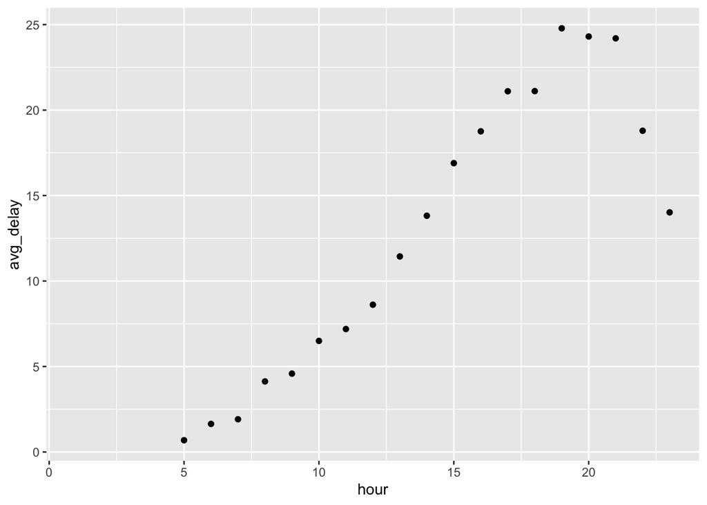

```r
flights |>
  group_by(hour) |>
  summarize(avg_delay = mean(dep_delay, na.rm = TRUE)) |>
  ggplot(aes(x=hour, y=avg_delay)) + geom_point()
```

4. **What happens if you supply a negative `n` to `slice_min()` and `slice_max()`?**

I will take from an example above where I was finding flights *most delayed* upon departure from each destination.

```r
# slice_max
flights |>
  group_by(dest) |>
  slice_max(dep_delay, n = -1) |>
  relocate(dest)
```

```
# A tibble: 336,762 × 19
# Groups:   dest [103]
   dest   year month   day dep_time sched_dep_time dep_delay arr_time
   <chr> <int> <int> <int>    <int>          <int>     <dbl>    <int>
 1 ABQ    2013    12    14     2223           2001       142      133
 2 ABQ    2013    12    17     2220           2001       139      120
 3 ABQ    2013     7    30     2212           2007       125       57
 4 ABQ    2013     9     2     2212           2007       125       48
 5 ABQ    2013     7    23     2206           2007       119      116
 6 ABQ    2013     5    10     2158           2001       117       53
 7 ABQ    2013     8     9     2159           2007       112       37
 8 ABQ    2013     6     8     2148           2001       107        9
 9 ABQ    2013     9    12     2147           2001       106       25
10 ABQ    2013    10    15     2146           2001       105      106
# ℹ 336,752 more rows
# ℹ 11 more variables: sched_arr_time <int>, arr_delay <dbl>, carrier <chr>,
#   flight <int>, tailnum <chr>, origin <chr>, air_time <dbl>, distance <dbl>,
#   hour <dbl>, minute <dbl>, time_hour <dttm>
```

```r
# slice_min
flights |>
  group_by(dest) |>
  slice_min(dep_delay, n = -1) |>
  relocate(dest)
```

```
# A tibble: 336,760 × 19
# Groups:   dest [103]
   dest   year month   day dep_time sched_dep_time dep_delay arr_time
   <chr> <int> <int> <int>    <int>          <int>     <dbl>    <int>
 1 ABQ    2013    11    20     1948           2000       -12     2236
 2 ABQ    2013     9    10     1949           2001       -12     2225
 3 ABQ    2013    11     1     1950           2000       -10     2226
 4 ABQ    2013    11     5     1950           2000       -10     2310
 5 ABQ    2013    11    15     1950           2000       -10     2304
 6 ABQ    2013    12    28     1951           2001       -10     2243
 7 ABQ    2013     9    18     1951           2001       -10     2210
 8 ABQ    2013    10    19     1950           1959        -9     2236
 9 ABQ    2013    10    26     1950           1959        -9     2217
10 ABQ    2013    11    10     1951           2000        -9     2258
# ℹ 336,750 more rows
# ℹ 11 more variables: sched_arr_time <int>, arr_delay <dbl>, carrier <chr>,
#   flight <int>, tailnum <chr>, origin <chr>, air_time <dbl>, distance <dbl>,
#   hour <dbl>, minute <dbl>, time_hour <dttm>
```

5. **Explain what `count()` does in terms of the dplyr verbs you just learned. What does the `sort` argument to `count()` do?**

The command `count()` will tally the number of times a particular combination appears.

For example:

```r
flights |>
  count(origin, dest, sort = TRUE)
```

```
# A tibble: 224 × 3
   origin dest      n
   <chr>  <chr> <int>
 1 JFK    LAX   11262
 2 LGA    ATL   10263
 3 LGA    ORD    8857
 4 JFK    SFO    8204
 5 LGA    CLT    6168
 6 EWR    ORD    6100
 7 JFK    BOS    5898
 8 LGA    MIA    5781
 9 JFK    MCO    5464
10 EWR    BOS    5327
# ℹ 214 more rows
```

The above code creates a tibble showing the number of times a unique origin-destination pair appears. There were 11,262 flights that flew from JFK to LAX in 2013. The `SORT` argument arranges them in descending order.

```r
flights |>
  count(origin, dest, carrier, sort = TRUE)
```

```
# A tibble: 439 × 4
   origin dest  carrier     n
   <chr>  <chr> <chr>   <int>
 1 LGA    ORD   AA       5694
 2 LGA    ATL   DL       5544
 3 LGA    DFW   AA       4836
 4 LGA    DCA   US       4716
 5 EWR    SFO   UA       4344
 6 LGA    BOS   US       4283
 7 EWR    IAH   UA       3973
 8 LGA    MIA   AA       3945
 9 EWR    ORD   UA       3822
10 EWR    LAX   UA       3764
# ℹ 429 more rows
```

This adds an additional column carrier to find unique origin-destination-carrier combinations. These, then, are unique carrier routes. The most frequent one is from LGA to ORD, flown by AA, occurring 5,694 times.

6. **Suppose we have the following tiny data frame:**

   ```r
   df <- tibble(
     x = 1:5,
     y = c("a", "b", "a", "a", "b"),
     z = c("K", "K", "L", "L", "K")
   )
   ```

   1. **Write down what you think the output will look like, then check if you were correct, and describe what `group_by()` does.**

   ```r
   df |>
     group_by(y)
   ```

   ```
   # A tibble: 5 × 3
   # Groups:   y [2]
         x y     z
     <int> <chr> <chr>
   1     1 a     K
   2     2 b     K
   3     3 a     L
   4     4 a     L
   5     5 b     K
   ```

   The command `group_by(y)` sorts the data frame into groups based on the column `y`. Since `y` has 2 values (“a” or “b”), the tibble is grouped by `y` into two groups.
   2. **Write down what you think the output will look like, then check if you were correct, and describe what `arrange()` does. Also comment on how it’s different from the `group_by()` in part (a)?**

   ```r
   df |> arrange(y)
   ```

   ```
   # A tibble: 5 × 3
         x y     z
     <int> <chr> <chr>
   1     1 a     K
   2     3 a     L
   3     4 a     L
   4     2 b     K
   5     5 b     K
   ```

   The command `arrange()` will sort by the values of the column selected. While `group_by()` doesn’t actually impact how the data appears, `arrange()` will change the order of the observations.
   3. **Write down what you think the output will look like, then check if you were correct, and describe what the pipeline does.**

   ```r
   df |>
     group_by(y) |>
     summarize(mean_x = mean(x))
   ```

   ```
   # A tibble: 2 × 2
     y     mean_x
     <chr>  <dbl>
   1 a       2.67
   2 b       3.5
   ```

   The output will take the mean value of the column `x` separately for the two groups of `y`. The pipeline instructs R to execute any subsequent operations split by the groups specified (in this case, the two groups of y).
   4. **Write down what you think the output will look like, then check if you were correct, and describe what the pipeline does. Then, comment on what the message says.**

   ```r
   df |>
     group_by(y, z) |>
     summarize(mean_x = mean(x))
   ```

   ```
   # A tibble: 3 × 3
   # Groups:   y [2]
     y     z     mean_x
     <chr> <chr>  <dbl>
   1 a     K        1
   2 a     L        3.5
   3 b     K        3.5
   ```

   The output will group observations into groups based on both y and z. There should be three rows- one row for when y=a & z= K, one row for when y=a & z = L, and one row for when y=b & z=K. There is not a row for when y=B and z=L since that pair does not exist in the original data frame. Again, the pipeline says for subsequent operations, sort by y and z.
   5. **Write down what you think the output will look like, then check if you were correct, and describe what the pipeline does. How is the output different from the one in part (d).**

   ```r
   df |>
     group_by(y, z) |>
     summarize(mean_x = mean(x), .groups = "drop")
   ```

   ```
   # A tibble: 3 × 3
     y     z     mean_x
     <chr> <chr>  <dbl>
   1 a     K        1
   2 a     L        3.5
   3 b     K        3.5
   ```

   The output Is identical, except it drops the error message that `summarize()` has grouped output by `'y'`.
   6. **Write down what you think the outputs will look like, then check if you were correct, and describe what each pipeline does. How are the outputs of the two pipelines different?**

```r
df |>
  group_by(y, z) |>
  summarize(mean_x = mean(x))
```

[output not shown]

```
# A tibble: 3 × 3
# Groups:   y [2]
  y     z     mean_x
  <chr> <chr>  <dbl>
1 a     K        1
2 a     L        3.5
3 b     K        3.5
```

```r
df |>
  group_by(y, z) |>
  mutate(mean_x = mean(x))
```

```
# A tibble: 5 × 4
# Groups:   y, z [3]
      x y     z     mean_x
  <int> <chr> <chr>  <dbl>
1     1 a     K        1
2     2 b     K        3.5
3     3 a     L        3.5
4     4 a     L        3.5
5     5 b     K        3.5
```

`Summarize()` will create the mean for `x` for all the rows that form a unique combination of `(y, z)`. Since there are three unique combinations, there are three rows in the tibble.

`Mutate()` will generate a new column with the value of the mean for each unique combination of `(y, z)`. While there are three unique combinations, they occur a total of five times, so there are five rows in the tibble (and a fourth column titled `mean_x`).